# Reducing Fuel misuse and Improving Profitability per Trip

Data Analytics II — Case Study 1: Exploratory & Inferential Analytics | AB InBev Sagamu Transport Operations — Q1 2026

Author

Anthonia Okocha

Published

May 23, 2026

Abstract

🎓 **Course:** Data Analytics II | 📋 **Assessment:** Capstone Case Study 1 | 👨‍🏫 **Instructor:** Prof Bongo Adi | 🏛️ **Institution:** Lagos Business School | 📅 **Date:** May 2026

# 1 Executive Summary

This study applies five exploratory and inferential analytics techniques to **1,073 truck-trip records** generated by AB InBev’s Sagamu Transport Operations hub between January and March 2026. The dataset was extracted directly from DP World MDS’s internal fleet management system and represents a complete census of all dispatched shipments over the quarter.

The central business problem is **fuel waste and its financial cost.** Across Q1 2026, 394 of 1,073 trips (36.7%) recorded positive fuel misuse, generating total losses of **₦30,472,200** — equivalent to approximately **₦122 million annually**. The analyses reveal that:

# 2 Professional Disclosure

## 2.1 Role and Organisation

I am a **Business Development Specialist** at **DP World**, a global ports, logistics, and supply chain conglomerate operating across 77 countries. Within the Nigerian Business Unit, my role sits in the commercial department where I am responsible for developing growth strategies, conducting cost modelling for commercial proposals, managing responses to tenders (RFIs, RFPs, RFQs), revising contract rates to optimise BU profitability, and identifying commercial risks pre- and post-contract execution.

The dataset analysed here — 1,073 truck trips dispatched from the Sagamu Transport Operations hub for AB InBev across Q1 2026 — comes directly from DP World’s internal fleet management system for a client account I manage commercially. Every variable maps to a metric I monitor: paid versus actual distance informs route pricing accuracy; fuel efficiency feeds into cost-per-kilometre benchmarks used in commercial proposals; misused fuel value quantifies the leakage that compresses BU profitability; and dead KM is a direct proxy for asset underutilisation — a KPI I am accountable for driving down.

## 2.2 Technique Operational Relevance

**Technique 1 — Exploratory Data Analysis:** A core deliverable in my role is *conducting cost modelling for commercial proposals*. No cost model is credible if built on unchecked data. Before I can price a rate for AB InBev or present a business case to BU leadership, I need to establish the true baseline of operational performance — not dashboard averages, but the full distribution of fuel costs including outliers, anomalies, and data quality failures that would distort the model. EDA on this dataset identifies impossible fuel efficiency readings, zero-distance trips, and severe right-skew in misused fuel value before any analysis is built on top of it.

**Technique 2 — Data Visualisation:** My role explicitly requires *supporting the preparation and presentation of commercial proposals* and driving *client engagements throughout the sales cycle*. Both activities demand visual communication — procurement directors and operations managers do not read regression tables; they read charts. The five visualisations in this project are structured as I would present them in a client quarterly business review: showing which destinations generate unsustainable waste, how performance varies across controllers, and how cost leakage trends month-on-month. A chart showing a client their own operational waste in naira terms is also a commercial tool — it builds the case for a revised contract structure or performance-linked rate.

**Technique 3 — Hypothesis Testing:** My role requires *supporting the identification and management of commercial risks pre, during, and post service engagement*. A key commercial risk in haulage is systematic underperformance by a specific controller team — because if persistent, it can trigger SLA breaches, erode client satisfaction scores, and threaten contract renewal. Before recommending a performance improvement plan, I need to confirm that the observed efficiency gap is statistically real and not a product of different route assignments. ANOVA provides that confirmation in a form that is defensible in a client performance meeting or an internal HR process.

**Technique 4 — Correlation Analysis:** My role requires *revising applicable rates to optimise income from existing clients* and *collaborating with other departments to determine the most cost-effective rate*. Both tasks require knowing which operational variables actually drive cost outcomes. If dead kilometres and misused fuel value are strongly correlated, then any contract that does not cap dead KM is absorbing an unpriced commercial risk — one that compresses the BU margin I am accountable for protecting. Correlation analysis maps these relationships before they are embedded into a pricing model or contract term.

**Technique 5 — Multiple Linear Regression:** My role requires *managing responses to RFIs, RFPs, and RFQs* and *negotiating commercial proposals*. Both tasks require me to defend a rate with data. Regression on this dataset produces the precise, coefficient-level answer I need: how much does each additional dead kilometre or extra day on the road add to misused fuel cost, holding all other factors constant? That number translates directly into a pricing adjustment, a contractual dead-KM cap, or a risk premium I can justify to a client or to BU finance.

# 3 Data Collection & Sampling

## 3.1 Source and Collection Method

The dataset was exported directly from **DP World’s** internal fleet management and trip-tracking platform, which records every shipment dispatched from the Sagamu Transport Operations hub for AB InBev. Data extraction was performed by downloading the Q1 trip review report for the period January 1 – March 31, 2026, in Excel format (`.xlsx`). The file (*TripReviewReport_ABNBEV_JAN_FEB_MAR.xlsx*) was accessed through the internal system available to me in my commercial role — the same system I use when preparing client performance reports and rate revision proposals for BU leadership.

All fields — including distances, fuel figures, and timestamps — are system-generated at the point of trip completion, with fuel reconciliation performed by fleet controllers upon vehicle return. No manual data entry was involved.

## 3.2 Sampling Frame and Sample Size

This dataset represents a **complete census** of all AB InBev trips dispatched from the Sagamu hub during Q1 2026. Every trip recorded in the system for the period is included. The final clean dataset contains **1,073 observations** across **20 variables**, comfortably exceeding the minimum requirement of 100 observations and 5 variables.

| Attribute | Detail |
| --- | --- |
| Client | AB InBev Nigeria |
| Operation Site | Sagamu Transport Operations |
| Operator | DP World MDS |
| Period Covered | 01 January 2026 – 31 March 2026 |
| Total Trips (raw) | 1,104 |
| Total Trips (clean) | 1,073 |
| Variables | 20 (6 numeric continuous, 4 numeric integer, 4 categorical, 2 datetime, 4 identifier/text) |
| Fleet Controllers | 5 individuals |
| Distinct Destinations | 40+ cities/states across Nigeria |

## 3.3 Variable Description

| Variable | Type | Description |
| --- | --- | --- |
| Shipment Number | Identifier | Unique trip ID |
| Fleet Controller | Categorical | Supervisor responsible for the trip |
| Vehicle | Categorical | Truck registration number |
| Delivery Officer | Categorical | Driver assigned |
| Created At | Date | Trip dispatch date |
| Completed At | Date | Trip completion date |
| Origin | Categorical | Departure location |
| Destination | Categorical | Delivery location |
| Paid Distance (KM) | Numeric | Contracted/agreed trip distance |
| Distance Covered (KM) | Numeric | Actual GPS-recorded distance |
| Fuel Budget (Litres) | Numeric | Approved fuel allocation |
| Fuel Used (Litres) | Numeric | Actual fuel consumed |
| Fuel Consumption | Numeric | Litres per 100 KM |
| Fuel Efficiency | Numeric | KM per litre ratio |
| Fuel Misused (Litres) | Numeric | Fuel used beyond budget |
| Dead KM | Numeric | Non-revenue kilometres driven |
| Misused Fuel Value (Naira) | **Outcome** | Financial cost of misused fuel (₦) |

## 3.4 Ethical Notes

Driver names and delivery officer identities are present in the operational data. For this published document, individuals are referenced only at the controller and vehicle level — no individual driver is singled out in the analysis. The data is used with organisational awareness for academic purposes under LBS guidelines.

# 4 Data Loading, Cleaning & Description

```r
df_raw <- read_excel("TripReviewReport_ABNBEV_JAN_FEB_MAR.xlsx")

cat("Raw dimensions:", nrow(df_raw), "rows x", ncol(df_raw), "columns\n")
```

```
Raw dimensions: 1104 rows x 20 columns
```

```r
df_raw %>%
  head(10) %>%
  kable(
    caption = "Preview of Raw Trip Review Dataset",
    align = "c",
    booktabs = TRUE
  ) %>%
  kable_styling(
    bootstrap_options = c("striped", "hover", "condensed", "responsive"),
    full_width = FALSE,
    position = "center",
    font_size = 13
  ) %>%
  row_spec(0,
           bold = TRUE,
           color = "white",
           background = "#1F4E79") %>%
  scroll_box(width = "100%", height = "400px")
```

Preview of Raw Trip Review Dataset

| S/N | Client | Shipment Number | Operation Site | Fleet Controller | Vehicle | Delivery Officer | Created At | Completed At | Origin | Destination | Paid Distance (KM) | Distance Covered(KM) | Fuel Budget (Litres) | Fuel Used (Litres) | Fuel Consumption | Fuel Efficiency | Fuel Misused(Litres) | Dead KM | Misused Fuel Value(Naira) |
| --- | --- | --- | --- | --- | --- | --- | --- | --- | --- | --- | --- | --- | --- | --- | --- | --- | --- | --- | --- |
| 1 | AB InBev | 206855 | Sagamu Transport Operations | Vincent Ojo | T32805LA | Alabi sunday Kayode | 02-Jan-2026 | 19-Jan-2026 | Sagamu | Lagos | 138 | 111 | 69 | 69 | 1.61 | 2.00 | 0 | 0 | 0 |
| 2 | AB InBev | 269651 | Sagamu Transport Operations | Vincent Ojo | T32822LA | Godfrey Braimoh | 02-Jan-2026 | 12-Jan-2026 | Ilesa | Abuja | 980 | 1270 | 490 | 626 | 2.03 | 1.57 | 136 | 290 | 258400 |
| 3 | AB InBev | 273737 | Sagamu Transport Operations | Dare Adediran | T32781LA | Izuka Goodluck | 23-Jan-2026 | 30-Jan-2026 | Sagamu | Abia | 1110 | 867 | 555 | 535 | 1.62 | 2.07 | 0 | 0 | 0 |
| 4 | AB InBev | 201603 | Sagamu Transport Operations | Vincent Ojo | T32808LA | Ajibola Najeem | 28-Jan-2026 | 02-Feb-2026 | Sagamu | Lagos | 164 | 136 | 82 | 78 | 1.74 | 2.10 | 0 | 0 | 0 |
| 5 | AB InBev | 201604 | Sagamu Transport Operations | Kayode Adebisi | T32791LA | Christopher Sunday | 29-Jan-2026 | 04-Feb-2026 | Sagamu | Oyo | 316 | 420 | 158 | 180 | 2.33 | 1.76 | 22 | 104 | 41800 |
| 6 | AB InBev | 201605 | Sagamu Transport Operations | OLUWADAMILARE ADENIRAN | T32752LA | Adekunle benson Ayomide | 29-Jan-2026 | 01-Feb-2026 | Sagamu | Lagos | 164 | 139 | 82 | 78 | 1.78 | 2.10 | 0 | 0 | 0 |
| 7 | AB InBev | 201606 | Sagamu Transport Operations | Vincent Ojo | T32815LA | Waheed Tajudeen | 28-Jan-2026 | 31-Jan-2026 | Sagamu | Oyo | 174 | 164 | 87 | 83 | 1.98 | 2.10 | 0 | 0 | 0 |
| 8 | AB InBev | 201607 | Sagamu Transport Operations | Kayode Adebisi | T32744LA | Adams Abdulsalam | 29-Jan-2026 | 02-Feb-2026 | Sagamu | Lagos | 280 | 284 | 140 | 133 | 2.14 | 2.11 | 0 | 4 | 0 |
| 9 | AB InBev | 201883 | Sagamu Transport Operations | Dare Adediran | T32794LA | Wasiu Bello | 17-Jan-2026 | 24-Jan-2026 | Sagamu | Anambra | 436 | 476 | 218 | 436 | 1.09 | 1.00 | 218 | 40 | 414200 |
| 10 | AB InBev | 237751 | Sagamu Transport Operations | OLUWADAMILARE ADENIRAN | T32771LA | Adesunmiboye Adeposi | 23-Jan-2026 | 30-Jan-2026 | Sagamu | Akwa Ibom | 1388 | 1196 | 694 | 618 | 1.94 | 2.25 | 0 | 0 | 0 |

```r
df <- df_raw |>
  rename(
    sn               = `S/N`,
    client           = Client,
    shipment_no      = `Shipment Number`,
    operation_site   = `Operation Site`,
    controller       = `Fleet Controller`,
    vehicle          = Vehicle,
    driver           = `Delivery Officer`,
    created_at       = `Created At`,
    completed_at     = `Completed At`,
    origin           = Origin,
    destination      = Destination,
    paid_km          = `Paid Distance (KM)`,
    actual_km        = `Distance Covered(KM)`,
    fuel_budget_L    = `Fuel Budget (Litres)`,
    fuel_used_L      = `Fuel Used (Litres)`,
    fuel_consumption = `Fuel Consumption`,
    fuel_efficiency  = `Fuel Efficiency`,
    fuel_misused_L   = `Fuel Misused(Litres)`,
    dead_km          = `Dead KM`,
    misused_value    = `Misused Fuel Value(Naira)`
  ) |>
  mutate(
    created_at        = dmy(created_at),
    completed_at      = dmy(completed_at),
    trip_days         = as.numeric(completed_at - created_at),
    month             = month(created_at, label = TRUE, abbr = FALSE),
    month_num         = month(created_at),
    km_variance       = actual_km - paid_km,
    fuel_over_budget  = fuel_used_L - fuel_budget_L,
    has_waste         = ifelse(misused_value > 0, "Waste", "No Waste"),
    controller        = str_to_title(controller),
    route_type        = case_when(
      paid_km <= 300  ~ "Short-haul (<=300 km)",
      paid_km <= 700  ~ "Medium-haul (301-700 km)",
      TRUE            ~ "Long-haul (>700 km)"
    ) |> factor(levels = c(
      "Short-haul (<=300 km)",
      "Medium-haul (301-700 km)",
      "Long-haul (>700 km)"
    ))
  )

# =========================
# DATA QUALITY SUMMARY
# =========================

quality_report <- tibble(
  Metric = c(
    "Total Rows",
    "Negative Trip Days",
    "Fuel Efficiency > 10",
    "Trips with Actual KM = 0"
  ),
  Value = c(
    nrow(df),
    sum(df$trip_days < 0, na.rm = TRUE),
    sum(df$fuel_efficiency > 10, na.rm = TRUE),
    sum(df$actual_km == 0, na.rm = TRUE)
  )
)

quality_report %>%
  kable(
    caption = "Data Quality Summary",
    align = "c",
    booktabs = TRUE
  ) %>%
  kable_styling(
    bootstrap_options = c("striped", "hover", "condensed", "responsive"),
    full_width = FALSE,
    position = "center",
    font_size = 13
  ) %>%
  row_spec(0, bold = TRUE, color = "white", background = "#1F4E79")
```

Data Quality Summary

| Metric | Value |
| --- | --- |
| Total Rows | 1104 |
| Negative Trip Days | 0 |
| Fuel Efficiency > 10 | 4 |
| Trips with Actual KM = 0 | 28 |

```r
# =========================
# MISSING VALUES REPORT
# =========================

missing_report <- tibble(
  Column = names(df),
  `Missing Values` = colSums(is.na(df))
)

missing_report %>%
  kable(
    caption = "Missing Values by Column",
    align = "c",
    booktabs = TRUE
  ) %>%
  kable_styling(
    bootstrap_options = c("striped", "hover", "responsive"),
    full_width = FALSE,
    position = "center",
    font_size = 12
  ) %>%
  row_spec(0, bold = TRUE, color = "white", background = "#7A0019") %>%
  scroll_box(width = "100%", height = "450px")
```

Missing Values by Column

| Column | Missing Values |
| --- | --- |
| sn | 0 |
| client | 0 |
| shipment_no | 0 |
| operation_site | 0 |
| controller | 0 |
| vehicle | 0 |
| driver | 0 |
| created_at | 0 |
| completed_at | 0 |
| origin | 0 |
| destination | 0 |
| paid_km | 0 |
| actual_km | 0 |
| fuel_budget_L | 0 |
| fuel_used_L | 0 |
| fuel_consumption | 0 |
| fuel_efficiency | 0 |
| fuel_misused_L | 0 |
| dead_km | 0 |
| misused_value | 0 |
| trip_days | 0 |
| month | 0 |
| month_num | 0 |
| km_variance | 0 |
| fuel_over_budget | 0 |
| has_waste | 0 |
| route_type | 0 |

```r
outlier_log <- df |>
  filter(fuel_efficiency > 10 | actual_km == 0 | trip_days < 0) |>
  select(sn, shipment_no, created_at, paid_km, actual_km, fuel_efficiency, trip_days)

cat("Records flagged for exclusion:", nrow(outlier_log), "\n")
```

```
Records flagged for exclusion: 31
```

```r
kable(outlier_log, caption = "Table 0: Flagged Records Before Exclusion") |>
  kable_styling(bootstrap_options = c("striped", "hover"), full_width = FALSE)
```

Table 0: Flagged Records Before Exclusion

| sn | shipment_no | created_at | paid_km | actual_km | fuel_efficiency | trip_days |
| --- | --- | --- | --- | --- | --- | --- |
| 367 | 275675 | 2026-02-05 | 168 | 0 | 2.63 | 1 |
| 397 | 275947 | 2026-02-05 | 952 | 0 | 2.00 | 9 |
| 499 | 278180 | 2026-02-14 | 174 | 0 | 2.76 | 5 |
| 502 | 278208 | 2026-02-13 | 146 | 113 | 146.00 | 3 |
| 506 | 278246 | 2026-02-18 | 152 | 0 | 2.11 | 1 |
| 582 | 279388 | 2026-02-19 | 280 | 0 | 21.54 | 18 |
| 602 | 279605 | 2026-02-19 | 1816 | 0 | 1.94 | 8 |
| 617 | 279904 | 2026-02-21 | 224 | 12 | 37.33 | 5 |
| 626 | 280151 | 2026-02-27 | 1188 | 0 | 1.91 | 7 |
| 646 | 280459 | 2026-02-23 | 1146 | 0 | 2.10 | 9 |
| 659 | 280813 | 2026-02-25 | 282 | 0 | 2.10 | 2 |
| 667 | 280964 | 2026-02-28 | 130 | 0 | 2.10 | 1 |
| 701 | 00126 | 2026-03-10 | 350 | 0 | 4.07 | 2 |
| 716 | 0035 | 2026-03-21 | 175 | 0 | 1.86 | 1 |
| 742 | 282045 | 2026-03-04 | 350 | 0 | 2.11 | 3 |
| 792 | 282922 | 2026-03-06 | 172 | 0 | 2.12 | 5 |
| 796 | 282976 | 2026-03-07 | 834 | 0 | 2.00 | 9 |
| 797 | 283050 | 2026-03-10 | 170 | 0 | 1.42 | 6 |
| 822 | 283905 | 2026-03-11 | 968 | 0 | 2.10 | 12 |
| 886 | 284676 | 2026-03-16 | 138 | 0 | 2.12 | 6 |
| 911 | 285055 | 2026-03-16 | 1026 | 0 | 1.86 | 14 |
| 969 | 286218 | 2026-03-22 | 1456 | 0 | 2.00 | 9 |
| 972 | 286316 | 2026-03-22 | 134 | 0 | 2.09 | 2 |
| 978 | 286384 | 2026-03-24 | 180 | 0 | 2.09 | 11 |
| 981 | 286465 | 2026-03-23 | 130 | 0 | 2.10 | 2 |
| 987 | 286502 | 2026-03-23 | 130 | 10 | 65.00 | 3 |
| 1026 | 287038 | 2026-03-25 | 478 | 0 | 1.93 | 4 |
| 1084 | 288178 | 2026-03-30 | 1188 | 0 | 1.91 | 10 |
| 1087 | 288213 | 2026-03-31 | 246 | 0 | 1.68 | 4 |
| 1096 | 288441 | 2026-03-31 | 144 | 0 | 0.00 | 1 |
| 1098 | 288447 | 2026-03-31 | 190 | 0 | 2.11 | 15 |

```r
# Rationale: fuel_efficiency > 10 km/L is physically impossible for a loaded truck
# (normal operating range: 1.5-3 km/L). actual_km == 0 indicates cancelled trips.
df_clean <- df |>
  filter(
    fuel_efficiency <= 10,
    actual_km > 0,
    trip_days >= 0
  )

cat("Clean dataset:", nrow(df_clean), "rows retained (",
    nrow(df) - nrow(df_clean), "rows removed)\n")
```

```
Clean dataset: 1073 rows retained ( 31 rows removed)
```

```r
summary_tbl <- df_clean |>
  select(paid_km, actual_km, fuel_budget_L, fuel_used_L,
         fuel_efficiency, fuel_misused_L, dead_km, misused_value, trip_days) |>
  pivot_longer(everything(), names_to = "Variable") |>
  group_by(Variable) |>
  summarise(
    N        = n(),
    Mean     = round(mean(value, na.rm = TRUE), 2),
    Median   = round(median(value, na.rm = TRUE), 2),
    SD       = round(sd(value, na.rm = TRUE), 2),
    Min      = round(min(value, na.rm = TRUE), 2),
    Max      = round(max(value, na.rm = TRUE), 2),
    Skewness = round(moments::skewness(value, na.rm = TRUE), 2)
  )

kable(summary_tbl,
      caption = "Table 1: Summary Statistics — Key Numeric Variables",
      format.args = list(big.mark = ",")) |>
  kable_styling(bootstrap_options = c("striped", "hover", "condensed"),
                full_width = FALSE) |>
  column_spec(8, bold = TRUE)
```

Table 1: Summary Statistics — Key Numeric Variables

| Variable | N | Mean | Median | SD | Min | Max | Skewness |
| --- | --- | --- | --- | --- | --- | --- | --- |
| actual_km | 1,073 | 705.91 | 568 | 543.82 | 2 | 3,151 | 0.80 |
| dead_km | 1,073 | 47.68 | 20 | 83.26 | 0 | 1,167 | 4.97 |
| fuel_budget_L | 1,073 | 346.77 | 337 | 255.58 | 32 | 1,489 | 0.66 |
| fuel_efficiency | 1,073 | 2.00 | 2 | 0.74 | -19 | 6 | -20.93 |
| fuel_misused_L | 1,073 | 14.95 | 0 | 31.48 | 0 | 342 | 3.97 |
| fuel_used_L | 1,073 | 350.26 | 357 | 265.48 | -10 | 1,518 | 0.76 |
| misused_value | 1,073 | 28,399.07 | 0 | 59,807.62 | 0 | 649,800 | 3.97 |
| paid_km | 1,073 | 693.49 | 674 | 511.21 | 64 | 2,978 | 0.66 |
| trip_days | 1,073 | 6.84 | 6 | 4.34 | 0 | 56 | 2.61 |

# 5 Technique 1 — Exploratory Data Analysis (EDA)

> **Business justification:** Before I can renegotiate a contract rate or build a proposal for a new client, I need an honest baseline of operational performance. EDA surfaces the true distribution of fuel costs, identifies anomalous trips (potential fraud, system errors, or route failures), and establishes whether reported performance figures are internally consistent — exactly what I do before every client quarterly business review.

## 5.1 Distribution of the Outcome Variable

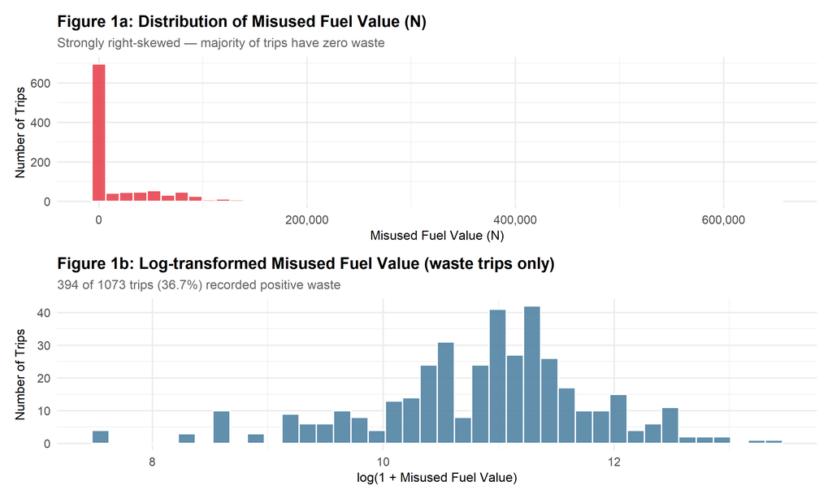

```r
p1 <- ggplot(df_clean, aes(x = misused_value)) +
  geom_histogram(bins = 50, fill = "#E63946", colour = "white", alpha = 0.85) +
  scale_x_continuous(labels = label_comma()) +
  labs(
    title    = "Figure 1a: Distribution of Misused Fuel Value (N)",
    subtitle = "Strongly right-skewed — majority of trips have zero waste",
    x        = "Misused Fuel Value (N)",
    y        = "Number of Trips"
  )

p2 <- ggplot(df_clean |> filter(misused_value > 0),
             aes(x = log1p(misused_value))) +
  geom_histogram(bins = 40, fill = "#457B9D", colour = "white", alpha = 0.85) +
  labs(
    title    = "Figure 1b: Log-transformed Misused Fuel Value (waste trips only)",
    subtitle = paste0(sum(df_clean$misused_value > 0), " of ", nrow(df_clean),
                      " trips (", round(mean(df_clean$misused_value > 0)*100, 1),
                      "%) recorded positive waste"),
    x        = "log(1 + Misused Fuel Value)",
    y        = "Number of Trips"
  )

p1 / p2
```

```r
waste_summary <- df_clean |>
  group_by(month) |>
  summarise(
    Total_Trips   = n(),
    Waste_Trips   = sum(misused_value > 0),
    Pct_Waste     = round(Waste_Trips / Total_Trips * 100, 1),
    Total_Waste_N = sum(misused_value),
    Avg_Waste_N   = round(mean(misused_value[misused_value > 0]), 0)
  )

kable(waste_summary,
      caption = "Table 2: Fuel Waste Summary by Month",
      col.names = c("Month", "Total Trips", "Waste Trips", "% with Waste",
                    "Total Waste (N)", "Avg Waste per Waste-Trip (N)"),
      format.args = list(big.mark = ",")) |>
  kable_styling(bootstrap_options = c("striped", "hover"), full_width = FALSE)
```

Table 2: Fuel Waste Summary by Month

| Month | Total Trips | Waste Trips | % with Waste | Total Waste (N) | Avg Waste per Waste-Trip (N) |
| --- | --- | --- | --- | --- | --- |
| January | 355 | 155 | 43.7 | 15,000,500 | 96,777 |
| February | 331 | 118 | 35.6 | 9,004,100 | 76,306 |
| March | 387 | 121 | 31.3 | 6,467,600 | 53,451 |

## 5.2 Data Quality Issues Identified and Resolved

Three data quality issues were identified and resolved prior to analysis:

```r
# Issue 1: Extreme fuel efficiency values
cat("ISSUE 1 - Fuel Efficiency Outliers:\n")
```

```
ISSUE 1 - Fuel Efficiency Outliers:
```

```r
cat("  Values > 10 km/L (physically impossible for loaded truck):",
    sum(df$fuel_efficiency > 10), "\n")
```

```
  Values > 10 km/L (physically impossible for loaded truck): 4
```

```r
cat("  Resolution: excluded from analysis\n\n")
```

```
  Resolution: excluded from analysis
```

```r
# Issue 2: Zero-distance trips
cat("ISSUE 2 - Incomplete/Cancelled Trips:\n")
```

```
ISSUE 2 - Incomplete/Cancelled Trips:
```

```r
cat("  Trips where actual_km = 0:", sum(df$actual_km == 0), "\n")
```

```
  Trips where actual_km = 0: 28
```

```r
cat("  Resolution: excluded as no operational activity occurred\n\n")
```

```
  Resolution: excluded as no operational activity occurred
```

```r
# Issue 3: Severe skewness in outcome variable
cat("ISSUE 3 - Right-Skew in Outcome Variable:\n")
```

```
ISSUE 3 - Right-Skew in Outcome Variable:
```

```r
cat("  Skewness of misused_value:",
    round(moments::skewness(df_clean$misused_value), 2), "\n")
```

```
  Skewness of misused_value: 3.97
```

```r
cat("  Resolution: log1p transformation applied in regression (Section 9)\n\n")
```

```
  Resolution: log1p transformation applied in regression (Section 9)
```

```r
# Retained: large km_variance trips
extreme_var <- df_clean |> filter(abs(km_variance) > 500)
cat("NOTE: Trips with |km_variance| > 500 km:", nrow(extreme_var),
    "- retained; large variances likely reflect genuine detours or route changes\n")
```

```
NOTE: Trips with |km_variance| > 500 km: 19 - retained; large variances likely reflect genuine detours or route changes
```

## 5.3 Distributions of Key Operational Variables

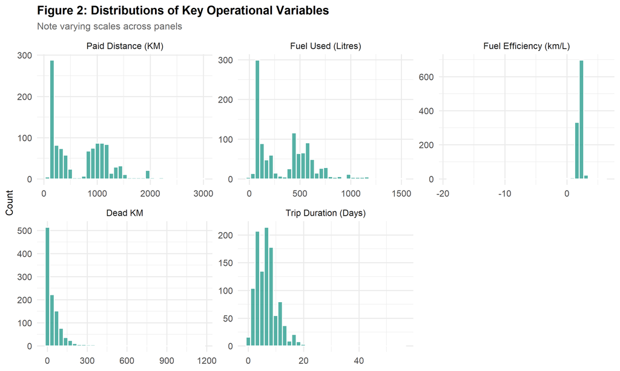

```r
vars_to_plot <- c("paid_km", "fuel_used_L", "fuel_efficiency", "dead_km", "trip_days")
labels_map   <- c(
  paid_km         = "Paid Distance (KM)",
  fuel_used_L     = "Fuel Used (Litres)",
  fuel_efficiency = "Fuel Efficiency (km/L)",
  dead_km         = "Dead KM",
  trip_days       = "Trip Duration (Days)"
)

df_clean |>
  select(all_of(vars_to_plot)) |>
  pivot_longer(everything(), names_to = "var", values_to = "val") |>
  mutate(var = factor(var, levels = vars_to_plot, labels = unname(labels_map))) |>
  ggplot(aes(x = val)) +
  geom_histogram(bins = 35, fill = "#2A9D8F", colour = "white", alpha = 0.8) +
  facet_wrap(~var, scales = "free", ncol = 3) +
  labs(
    title    = "Figure 2: Distributions of Key Operational Variables",
    subtitle = "Note varying scales across panels",
    x = NULL, y = "Count"
  )
```

# 6 Technique 2 — Data Visualisation

> **Business justification:** I present performance dashboards to both internal management and external clients. The five visualisations below replicate the format of a commercial review deck — showing controller efficiency gaps, monthly waste trends, and dead-kilometre concentration by route in a form that drives an executive decision, not further analysis.

## 6.1 Monthly Trip Volume and Waste Cost

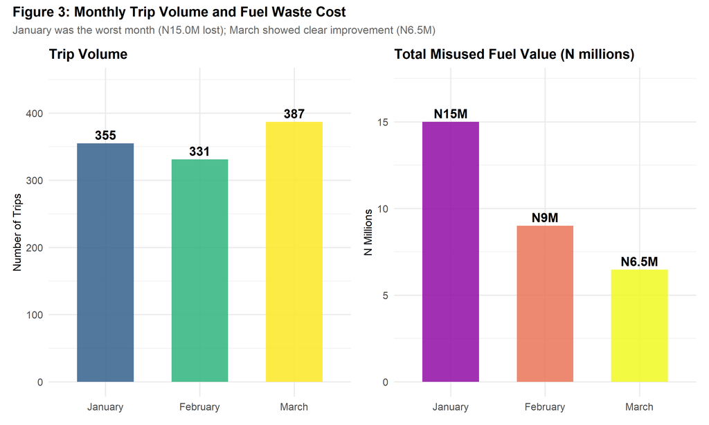

```r
monthly_data <- df_clean |>
  group_by(month) |>
  summarise(
    trips       = n(),
    waste_pct   = mean(misused_value > 0) * 100,
    total_waste = sum(misused_value) / 1e6
  )

p_vol <- ggplot(monthly_data, aes(x = month, y = trips, fill = month)) +
  geom_col(show.legend = FALSE, alpha = 0.85, width = 0.6) +
  scale_fill_viridis_d(option = "D", begin = 0.3) +
  geom_text(aes(label = trips), vjust = -0.4, fontface = "bold") +
  labs(title = "Trip Volume", x = NULL, y = "Number of Trips") +
  ylim(0, max(monthly_data$trips) * 1.15)

p_waste <- ggplot(monthly_data, aes(x = month, y = total_waste, fill = month)) +
  geom_col(show.legend = FALSE, alpha = 0.85, width = 0.6) +
  scale_fill_viridis_d(option = "C", begin = 0.3) +
  geom_text(aes(label = paste0("N", round(total_waste, 1), "M")),
            vjust = -0.4, fontface = "bold") +
  labs(title = "Total Misused Fuel Value (N millions)", x = NULL, y = "N Millions") +
  ylim(0, max(monthly_data$total_waste) * 1.15)

(p_vol | p_waste) +
  plot_annotation(
    title    = "Figure 3: Monthly Trip Volume and Fuel Waste Cost",
    subtitle = "January was the worst month (N15.0M lost); March showed clear improvement (N6.5M)"
  )
```

## 6.2 Fuel Waste by Fleet Controller

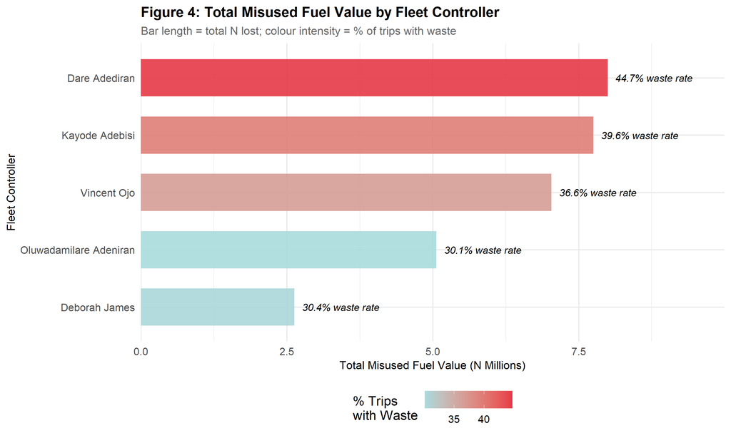

```r
controller_data <- df_clean |>
  group_by(controller) |>
  summarise(
    trips       = n(),
    waste_trips = sum(misused_value > 0),
    waste_pct   = waste_trips / trips * 100,
    avg_waste   = mean(misused_value[misused_value > 0]),
    total_waste = sum(misused_value)
  ) |>
  arrange(desc(total_waste))

ggplot(controller_data,
       aes(x = reorder(controller, total_waste),
           y = total_waste / 1e6, fill = waste_pct)) +
  geom_col(alpha = 0.9, width = 0.65) +
  geom_text(aes(label = paste0(round(waste_pct, 1), "% waste rate")),
            hjust = -0.1, size = 3.5, fontface = "italic") +
  coord_flip() +
  scale_fill_gradient(low = "#A8DADC", high = "#E63946",
                      name = "% Trips\nwith Waste") +
  scale_y_continuous(labels = label_comma(),
                     expand = expansion(mult = c(0, 0.25))) +
  labs(
    title    = "Figure 4: Total Misused Fuel Value by Fleet Controller",
    subtitle = "Bar length = total N lost; colour intensity = % of trips with waste",
    x = "Fleet Controller", y = "Total Misused Fuel Value (N Millions)"
  )
```

## 6.3 Fuel Waste Distribution by Route Type

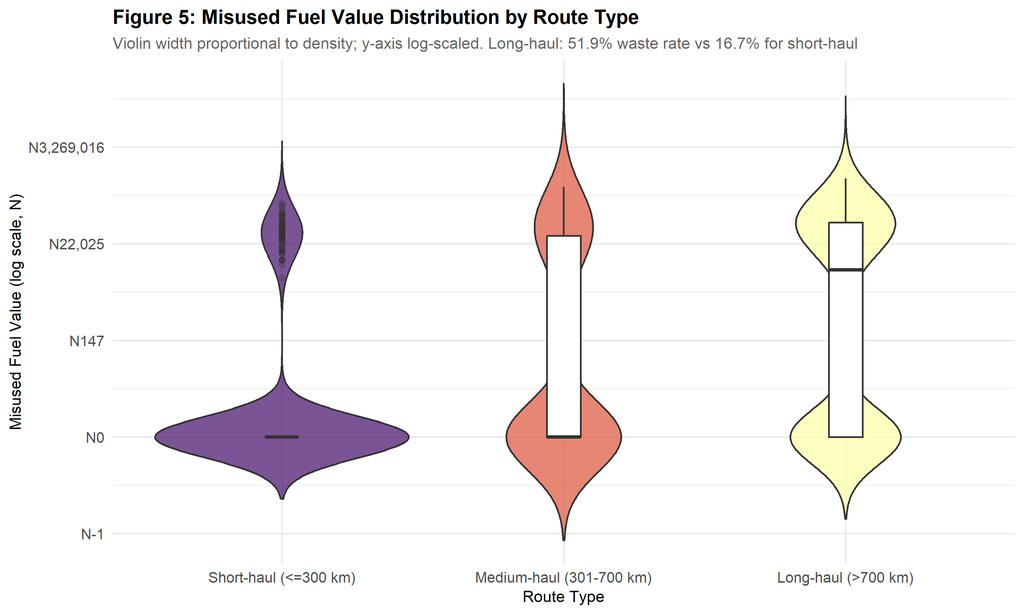

```r
ggplot(df_clean,
       aes(x = route_type, y = log1p(misused_value), fill = route_type)) +
  geom_violin(alpha = 0.7, trim = FALSE, show.legend = FALSE) +
  geom_boxplot(width = 0.12, fill = "white", outlier.alpha = 0.3,
               show.legend = FALSE) +
  scale_fill_viridis_d(option = "B", begin = 0.2) +
  scale_y_continuous(
    labels = function(x) paste0("N", comma(round(expm1(x))))
  ) +
  labs(
    title    = "Figure 5: Misused Fuel Value Distribution by Route Type",
    subtitle = "Violin width proportional to density; y-axis log-scaled. Long-haul: 51.9% waste rate vs 16.7% for short-haul",
    x = "Route Type", y = "Misused Fuel Value (log scale, N)"
  )
```

## 6.4 Top 15 Destinations by Average Waste

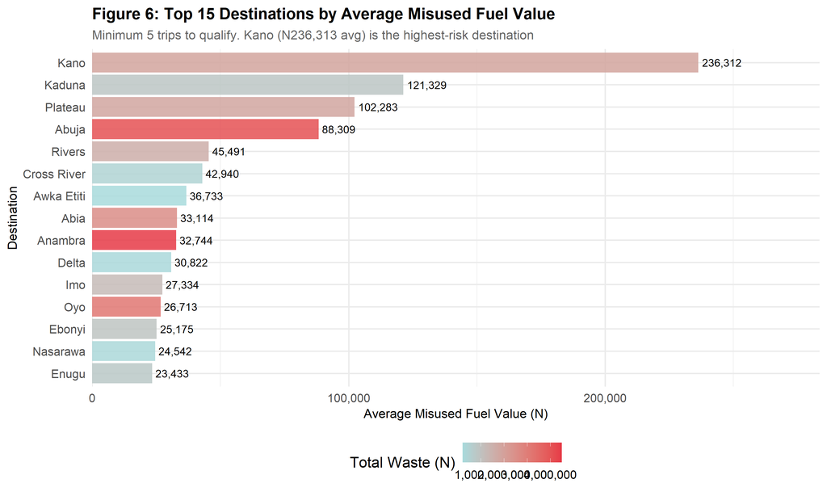

```r
dest_data <- df_clean |>
  group_by(destination) |>
  summarise(
    trips     = n(),
    avg_waste = mean(misused_value),
    tot_waste = sum(misused_value)
  ) |>
  filter(trips >= 5) |>
  slice_max(avg_waste, n = 15)

ggplot(dest_data,
       aes(x = reorder(destination, avg_waste), y = avg_waste, fill = tot_waste)) +
  geom_col(alpha = 0.85) +
  geom_text(aes(label = comma(round(avg_waste))), hjust = -0.1, size = 3.3) +
  coord_flip() +
  scale_fill_gradient(low = "#A8DADC", high = "#E63946",
                      labels = label_comma(), name = "Total Waste (N)") +
  scale_y_continuous(labels = label_comma(),
                     expand = expansion(mult = c(0, 0.2))) +
  labs(
    title    = "Figure 6: Top 15 Destinations by Average Misused Fuel Value",
    subtitle = "Minimum 5 trips to qualify. Kano (N236,313 avg) is the highest-risk destination",
    x = "Destination", y = "Average Misused Fuel Value (N)"
  )
```

## 6.5 Weekly Fuel Efficiency Trend by Controller

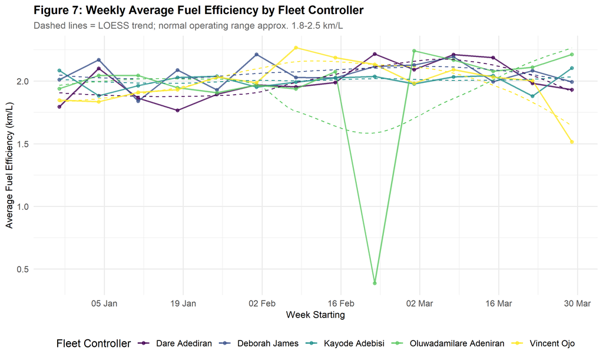

```r
weekly_eff <- df_clean |>
  mutate(week = floor_date(created_at, "week")) |>
  group_by(week, controller) |>
  summarise(avg_eff = mean(fuel_efficiency), .groups = "drop")

ggplot(weekly_eff, aes(x = week, y = avg_eff, colour = controller)) +
  geom_line(linewidth = 0.8, alpha = 0.8) +
  geom_point(size = 1.5, alpha = 0.7) +
  geom_smooth(se = FALSE, method = "loess", linetype = "dashed",
              linewidth = 0.5, alpha = 0.5) +
  scale_colour_viridis_d(option = "D", name = "Fleet Controller") +
  scale_x_date(date_breaks = "2 weeks", date_labels = "%d %b") +
  labs(
    title    = "Figure 7: Weekly Average Fuel Efficiency by Fleet Controller",
    subtitle = "Dashed lines = LOESS trend; normal operating range approx. 1.8-2.5 km/L",
    x = "Week Starting", y = "Average Fuel Efficiency (km/L)"
  )
```

**Narrative summary:** The five visualisations tell a coherent story. January was the most wasteful month (N15.0M in losses), but March showed measurable improvement (N6.5M), suggesting interventions may already be having some effect. Long-haul trips generate dramatically more waste than short-haul (Figure 5). Dare Adediran’s team has the highest waste rate (44.7%) while Deborah James has the lowest average waste per trip (N19,479). Kano, Kaduna, and Plateau are the highest-risk destinations (Figure 6). These patterns set up the formal testing in Section 7.

# 7 Technique 3 — Hypothesis Testing

> **Business justification:** Before recommending that a controller be placed on a performance improvement plan — a commercially sensitive decision with HR and contractual implications — I need to confirm that the observed efficiency gap is statistically real and not a product of different route assignments. ANOVA provides that confirmation. Without it, any intervention recommendation is legally and commercially vulnerable to challenge.

## 7.1 Hypothesis 1 — Does Fuel Efficiency Differ Across Fleet Controllers?

**Business question:** Are all five fleet controllers managing their fleets equally efficiently, or are some systematically associated with better or worse fuel economy?

**H₀:** Mean fuel efficiency is equal across all five fleet controllers (μ₁ = μ₂ = μ₃ = μ₄ = μ₅).  
**H₁:** At least one fleet controller’s mean fuel efficiency differs from the others.  
**Test:** Welch one-way ANOVA (robust to unequal group variances). Significance level: α = 0.05.

```r
cat("=== Shapiro-Wilk Normality Test by Controller ===\n")
```

```
=== Shapiro-Wilk Normality Test by Controller ===
```

```r
df_clean |>
  group_by(controller) |>
  summarise(
    n         = n(),
    W_stat    = shapiro.test(fuel_efficiency)$statistic,
    p_value   = shapiro.test(fuel_efficiency)$p.value,
    Skewness  = round(moments::skewness(fuel_efficiency), 3)
  ) |>
  kable(digits = 4, caption = "Shapiro-Wilk Normality Test by Fleet Controller") |>
  kable_styling(bootstrap_options = c("striped", "hover"), full_width = FALSE)
```

Shapiro-Wilk Normality Test by Fleet Controller

| controller | n | W_stat | p_value | Skewness |
| --- | --- | --- | --- | --- |
| Dare Adediran | 208 | 0.6572 | 0 | 3.461 |
| Deborah James | 135 | 0.6192 | 0 | 4.369 |
| Kayode Adebisi | 250 | 0.7706 | 0 | -0.097 |
| Oluwadamilare Adeniran | 226 | 0.1376 | 0 | -13.807 |
| Vincent Ojo | 254 | 0.6865 | 0 | 2.119 |

```r
levene_result <- leveneTest(fuel_efficiency ~ controller, data = df_clean)

levene_tbl <- as.data.frame(levene_result) |>
  rownames_to_column("Test") |>
  mutate(across(where(is.numeric), ~round(.x, 4)))

levene_tbl %>%
  kable(
    caption = "Levene’s Test for Homogeneity of Variance",
    align = "c",
    booktabs = TRUE
  ) %>%
  kable_styling(
    bootstrap_options = c("striped", "hover", "condensed", "responsive"),
    full_width = FALSE,
    position = "center",
    font_size = 13
  ) %>%
  row_spec(0, bold = TRUE, color = "white", background = "#1F4E79")
```

Levene’s Test for Homogeneity of Variance

| Test | Df | F value | Pr(>F) |
| --- | --- | --- | --- |
| group | 4 | 0.8713 | 0.4805 |
|  | 1068 | NA | NA |

```r
p_val <- levene_result$`Pr(>F)`[1]

tibble(
  Interpretation = c(
    paste0("p-value = ", round(p_val, 4)),
    ifelse(p_val < 0.05,
           "Reject H0: Variances are not equal",
           "Fail to reject H0: Variances are equal"),
    "Recommendation: Use Welch ANOVA (robust to unequal variances)"
  )
) %>%
  kable(
    caption = "Statistical Interpretation",
    align = "l",
    booktabs = TRUE
  ) %>%
  kable_styling(
    bootstrap_options = c("striped", "hover", "responsive"),
    full_width = FALSE,
    position = "center",
    font_size = 12
  )
```

Statistical Interpretation

| Interpretation |
| --- |
| p-value = 0.4805 |
| Fail to reject H0: Variances are equal |
| Recommendation: Use Welch ANOVA (robust to unequal variances) |

```r
# =========================
# Welch ANOVA
# =========================

welch_result <- oneway.test(
  fuel_efficiency ~ controller,
  data = df_clean,
  var.equal = FALSE
)

welch_tbl <- tibble(
  Statistic = unname(welch_result$statistic),
  Parameter = unname(welch_result$parameter),
  `P-value` = welch_result$p.value
) |>
  mutate(across(where(is.numeric), ~round(.x, 4)))

welch_tbl %>%
  kable(
    caption = "Welch ANOVA Result (Fuel Efficiency by Controller)",
    align = "c",
    booktabs = TRUE
  ) %>%
  kable_styling(
    bootstrap_options = c("striped", "hover", "condensed", "responsive"),
    full_width = FALSE,
    position = "center",
    font_size = 13
  ) %>%
  row_spec(0, bold = TRUE, color = "white", background = "#1F4E79")
```

Welch ANOVA Result (Fuel Efficiency by Controller)

| Statistic | Parameter | P-value |
| --- | --- | --- |
| 0.5061 | 4.000 | 0.7313 |
| 0.5061 | 471.068 | 0.7313 |

```r
# =========================
# Effect Size (Eta Squared)
# =========================

aov_result <- aov(fuel_efficiency ~ controller, data = df_clean)
eta_sq <- eta_squared(aov_result, partial = FALSE)

eta_value <- eta_sq$Eta2[1]

effect_label <- ifelse(
  eta_value < 0.01, "Negligible",
  ifelse(
    eta_value < 0.06, "Small",
    ifelse(
      eta_value < 0.14, "Medium",
      "Large"
    )
  )
)

eta_tbl <- tibble(
  Metric = "Eta Squared",
  Value = round(eta_value, 4),
  Interpretation = effect_label
)

eta_tbl %>%
  kable(
    caption = "Effect Size (Eta Squared) for Controller Impact on Fuel Efficiency",
    align = "c",
    booktabs = TRUE
  ) %>%
  kable_styling(
    bootstrap_options = c("striped", "hover", "responsive"),
    full_width = FALSE,
    position = "center",
    font_size = 13
  ) %>%
  row_spec(0, bold = TRUE, color = "white", background = "#7A0019")
```

Effect Size (Eta Squared) for Controller Impact on Fuel Efficiency

| Metric | Value | Interpretation |
| --- | --- | --- |
| Eta Squared | 0.0016 | Negligible |

```r
# =========================
# PAIRWISE T-TEST
# =========================

ph <- pairwise.t.test(
  df_clean$fuel_efficiency,
  df_clean$controller,
  p.adjust.method = "bonferroni"
)

ph_tbl <- as.data.frame(as.table(as.matrix(ph$p.value))) |>
  rename(
    Group1 = Var1,
    Group2 = Var2,
    `P-value` = Freq
  ) |>
  filter(!is.na(`P-value`)) |>
  mutate(`P-value` = round(`P-value`, 4))

ph_tbl %>%
  kable(
    caption = "Pairwise Comparisons (Bonferroni-adjusted)",
    align = "c",
    booktabs = TRUE
  ) %>%
  kable_styling(
    bootstrap_options = c("striped", "hover", "condensed", "responsive"),
    full_width = FALSE,
    position = "center",
    font_size = 13
  ) %>%
  row_spec(0, bold = TRUE, color = "white", background = "#1F4E79")
```

Pairwise Comparisons (Bonferroni-adjusted)

| Group1 | Group2 | P-value |
| --- | --- | --- |
| Deborah James | Dare Adediran | 1 |
| Kayode Adebisi | Dare Adediran | 1 |
| Oluwadamilare Adeniran | Dare Adediran | 1 |
| Vincent Ojo | Dare Adediran | 1 |
| Kayode Adebisi | Deborah James | 1 |
| Oluwadamilare Adeniran | Deborah James | 1 |
| Vincent Ojo | Deborah James | 1 |
| Oluwadamilare Adeniran | Kayode Adebisi | 1 |
| Vincent Ojo | Kayode Adebisi | 1 |
| Vincent Ojo | Oluwadamilare Adeniran | 1 |

```r
# =========================
# GROUP SUMMARY TABLE
# =========================

group_means <- df_clean |>
  group_by(controller) |>
  summarise(
    n          = n(),
    Mean_Eff   = mean(fuel_efficiency, na.rm = TRUE),
    Median_Eff = median(fuel_efficiency, na.rm = TRUE),
    SD_Eff     = sd(fuel_efficiency, na.rm = TRUE),
    .groups = "drop"
  ) |>
  mutate(across(where(is.numeric), ~round(.x, 3))) |>
  arrange(desc(Mean_Eff))

group_means %>%
  kable(
    caption = "Fuel Efficiency Summary by Fleet Controller",
    col.names = c("Controller", "N", "Mean (km/L)", "Median (km/L)", "SD"),
    align = "c",
    booktabs = TRUE
  ) %>%
  kable_styling(
    bootstrap_options = c("striped", "hover", "condensed", "responsive"),
    full_width = FALSE,
    position = "center",
    font_size = 13
  ) %>%
  row_spec(0, bold = TRUE, color = "white", background = "#7A0019")
```

Fuel Efficiency Summary by Fleet Controller

| Controller | N | Mean (km/L) | Median (km/L) | SD |
| --- | --- | --- | --- | --- |
| Deborah James | 135 | 2.050 | 2 | 0.387 |
| Dare Adediran | 208 | 2.019 | 2 | 0.501 |
| Vincent Ojo | 254 | 2.011 | 2 | 0.350 |
| Kayode Adebisi | 250 | 2.003 | 2 | 0.278 |
| Oluwadamilare Adeniran | 226 | 1.953 | 2 | 1.435 |

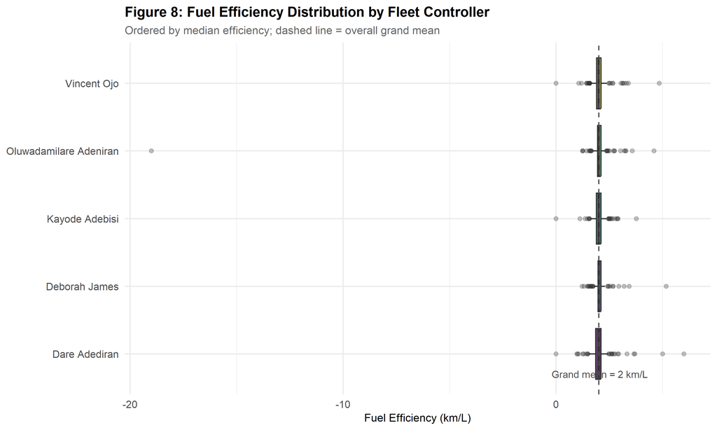

```r
ggplot(df_clean,
       aes(x = reorder(controller, fuel_efficiency, median),
           y = fuel_efficiency, fill = controller)) +
  geom_boxplot(alpha = 0.75, outlier.alpha = 0.3, show.legend = FALSE) +
  geom_hline(yintercept = mean(df_clean$fuel_efficiency),
             linetype = "dashed", colour = "grey30") +
  annotate("text", x = 0.7,
           y = mean(df_clean$fuel_efficiency) + 0.05,
           label = paste0("Grand mean = ",
                          round(mean(df_clean$fuel_efficiency), 2), " km/L"),
           size = 3.5, colour = "grey30") +
  scale_fill_viridis_d(option = "D") +
  coord_flip() +
  labs(
    title    = "Figure 8: Fuel Efficiency Distribution by Fleet Controller",
    subtitle = "Ordered by median efficiency; dashed line = overall grand mean",
    x = NULL, y = "Fuel Efficiency (km/L)"
  )
```

## 7.2 Hypothesis 2 — Do Waste Rates Differ by Route Type?

**Business question:** Does route distance category affect whether a trip generates any fuel waste — and is that difference statistically real?

**H₀:** The proportion of waste-generating trips is equal across short-haul, medium-haul, and long-haul routes.  
**H₁:** At least one route type has a significantly different waste rate.  
**Test:** Pearson chi-squared test of independence. Significance level: α = 0.05.

```r
# =========================
# CONTINGENCY TABLE
# =========================

ct <- table(df_clean$route_type, df_clean$has_waste)

ct_tbl <- as.data.frame.matrix(ct) |>
  tibble::rownames_to_column("Route Type")

ct_tbl %>%
  kable(
    caption = "Contingency Table: Route Type vs Fuel Waste",
    align = "c",
    booktabs = TRUE
  ) %>%
  kable_styling(
    bootstrap_options = c("striped", "hover", "condensed", "responsive"),
    full_width = FALSE,
    position = "center",
    font_size = 13
  ) %>%
  row_spec(0, bold = TRUE, color = "white", background = "#1F4E79")
```

Contingency Table: Route Type vs Fuel Waste

| Route Type | No Waste | Waste |
| --- | --- | --- |
| Short-haul (<=300 km) | 339 | 68 |
| Medium-haul (301-700 km) | 82 | 48 |
| Long-haul (>700 km) | 258 | 278 |

```r
# =========================
# ROW PROPORTIONS
# =========================

row_prop <- prop.table(ct, margin = 1)

row_prop_tbl <- as.data.frame.matrix(round(row_prop, 3)) |>
  tibble::rownames_to_column("Route Type")

row_prop_tbl %>%
  kable(
    caption = "Row Proportions: Waste Distribution by Route Type",
    align = "c",
    booktabs = TRUE
  ) %>%
  kable_styling(
    bootstrap_options = c("striped", "hover", "responsive"),
    full_width = FALSE,
    position = "center",
    font_size = 12
  ) %>%
  row_spec(0, bold = TRUE, color = "white", background = "#7A0019")
```

Row Proportions: Waste Distribution by Route Type

| Route Type | No Waste | Waste |
| --- | --- | --- |
| Short-haul (<=300 km) | 0.833 | 0.167 |
| Medium-haul (301-700 km) | 0.631 | 0.369 |
| Long-haul (>700 km) | 0.481 | 0.519 |

```r
# =========================
# CHI-SQUARE TEST
# =========================

chi_result <- chisq.test(ct)

chi_tbl <- tibble(
  Statistic = unname(chi_result$statistic),
  DF = unname(chi_result$parameter),
  `P-value` = chi_result$p.value
) |>
  mutate(across(where(is.numeric), ~round(.x, 4)))

chi_tbl %>%
  kable(
    caption = "Chi-Square Test: Route Type vs Fuel Waste",
    align = "c",
    booktabs = TRUE
  ) %>%
  kable_styling(
    bootstrap_options = c("striped", "hover", "condensed", "responsive"),
    full_width = FALSE,
    position = "center",
    font_size = 13
  ) %>%
  row_spec(0, bold = TRUE, color = "white", background = "#1F4E79")
```

Chi-Square Test: Route Type vs Fuel Waste

| Statistic | DF | P-value |
| --- | --- | --- |
| 123.0665 | 2 | 0 |

```r
# =========================
# CRAMER'S V (EFFECT SIZE)
# =========================

cv <- sqrt(
  chi_result$statistic /
    (sum(ct) * (min(dim(ct)) - 1))
)

effect_label <- ifelse(
  cv < 0.1, "Negligible",
  ifelse(
    cv < 0.3, "Small",
    ifelse(
      cv < 0.5, "Medium",
      "Large"
    )
  )
)

cv_tbl <- tibble(
  Metric = "Cramer's V",
  Value = round(as.numeric(cv), 4),
  Interpretation = effect_label
)

cv_tbl %>%
  kable(
    caption = "Effect Size: Association Strength (Route Type vs Waste)",
    align = "c",
    booktabs = TRUE
  ) %>%
  kable_styling(
    bootstrap_options = c("striped", "hover", "responsive"),
    full_width = FALSE,
    position = "center",
    font_size = 13
  ) %>%
  row_spec(0, bold = TRUE, color = "white", background = "#7A0019")
```

Effect Size: Association Strength (Route Type vs Waste)

| Metric | Value | Interpretation |
| --- | --- | --- |
| Cramer's V | 0.3387 | Medium |

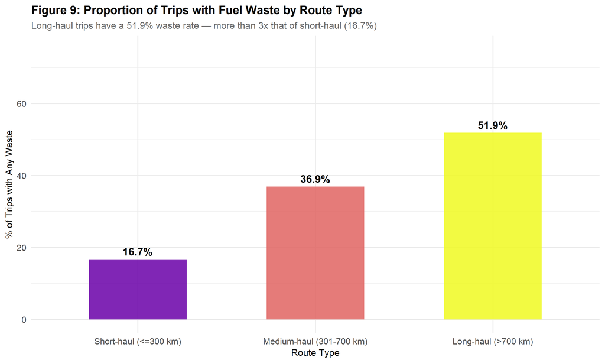

```r
df_clean |>
  count(route_type, has_waste) |>
  group_by(route_type) |>
  mutate(pct = n / sum(n) * 100) |>
  filter(has_waste == "Waste") |>
  ggplot(aes(x = route_type, y = pct, fill = route_type)) +
  geom_col(alpha = 0.85, show.legend = FALSE, width = 0.55) +
  geom_text(aes(label = paste0(round(pct, 1), "%")),
            vjust = -0.5, fontface = "bold", size = 4.5) +
  scale_fill_viridis_d(option = "C", begin = 0.2) +
  scale_y_continuous(limits = c(0, 75)) +
  labs(
    title    = "Figure 9: Proportion of Trips with Fuel Waste by Route Type",
    subtitle = "Long-haul trips have a 51.9% waste rate — more than 3x that of short-haul (16.7%)",
    x = "Route Type", y = "% of Trips with Any Waste"
  )
```

**Business implication:** Route type is a contractual variable. Long-haul routes should carry a higher fuel risk premium in the contract rate structure, and pre-trip fuel verification should be mandatory for all trips exceeding 700 km — a practice not consistently applied in the current Q1 data.

# 8 Technique 4 — Correlation Analysis

> **Business justification:** Pricing a logistics contract accurately requires understanding which cost drivers actually move together. If dead kilometres and fuel misuse are strongly correlated, then a contract that does not cap dead KM is implicitly absorbing an unpriced risk. Correlation analysis maps these relationships before they are embedded into a pricing model, preventing the BU from underpricing a risk it has not yet quantified.

## 8.1 Pearson Correlation Matrix

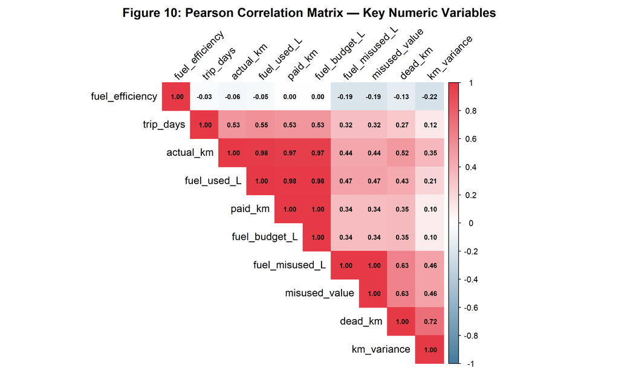

```r
corr_vars <- df_clean |>
  select(paid_km, actual_km, fuel_budget_L, fuel_used_L,
         fuel_efficiency, fuel_misused_L, dead_km,
         misused_value, trip_days, km_variance)

corr_matrix <- cor(corr_vars, method = "pearson", use = "complete.obs")

corrplot(corr_matrix,
         method      = "color",
         type        = "upper",
         order       = "hclust",
         addCoef.col = "black",
         number.cex  = 0.65,
         tl.col      = "black",
         tl.srt      = 45,
         col         = colorRampPalette(c("#457B9D", "white", "#E63946"))(200),
         title       = "Figure 10: Pearson Correlation Matrix — Key Numeric Variables",
         mar         = c(0, 0, 2, 0))
```

## 8.2 Spearman Correlations with Misused Fuel Value

```r
spearman_tbl <- corr_vars |>
  select(-misused_value) |>
  map(\(col) {
    test <- cor.test(col, corr_vars$misused_value,
                     method = "spearman", exact = FALSE)
    tibble(rho = test$estimate, p_value = test$p.value)
  }) |>
  list_rbind(names_to = "Variable") |>
  mutate(
    Significant = ifelse(p_value < 0.05, "Yes", "No"),
    Strength    = case_when(
      abs(rho) >= 0.5 ~ "Strong",
      abs(rho) >= 0.3 ~ "Moderate",
      abs(rho) >= 0.1 ~ "Weak",
      TRUE            ~ "Negligible"
    )
  ) |>
  arrange(desc(abs(rho)))

kable(spearman_tbl,
      digits = 4,
      caption = "Table 4: Spearman Correlations with Misused Fuel Value (N)",
      col.names = c("Variable", "rho (Spearman)", "p-value",
                    "Significant", "Strength")) |>
  kable_styling(bootstrap_options = c("striped", "hover"), full_width = FALSE) |>
  row_spec(which(spearman_tbl$Significant == "Yes"), background = "#f0f7f0")
```

Table 4: Spearman Correlations with Misused Fuel Value (N)

| Variable | rho (Spearman) | p-value | Significant | Strength |
| --- | --- | --- | --- | --- |
| fuel_misused_L | 1.0000 | 0 | Yes | Strong |
| fuel_efficiency | -0.8367 | 0 | Yes | Strong |
| dead_km | 0.6528 | 0 | Yes | Strong |
| km_variance | 0.6328 | 0 | Yes | Strong |
| fuel_used_L | 0.5091 | 0 | Yes | Strong |
| actual_km | 0.4731 | 0 | Yes | Moderate |
| trip_days | 0.3758 | 0 | Yes | Moderate |
| paid_km | 0.3659 | 0 | Yes | Moderate |
| fuel_budget_L | 0.3659 | 0 | Yes | Moderate |

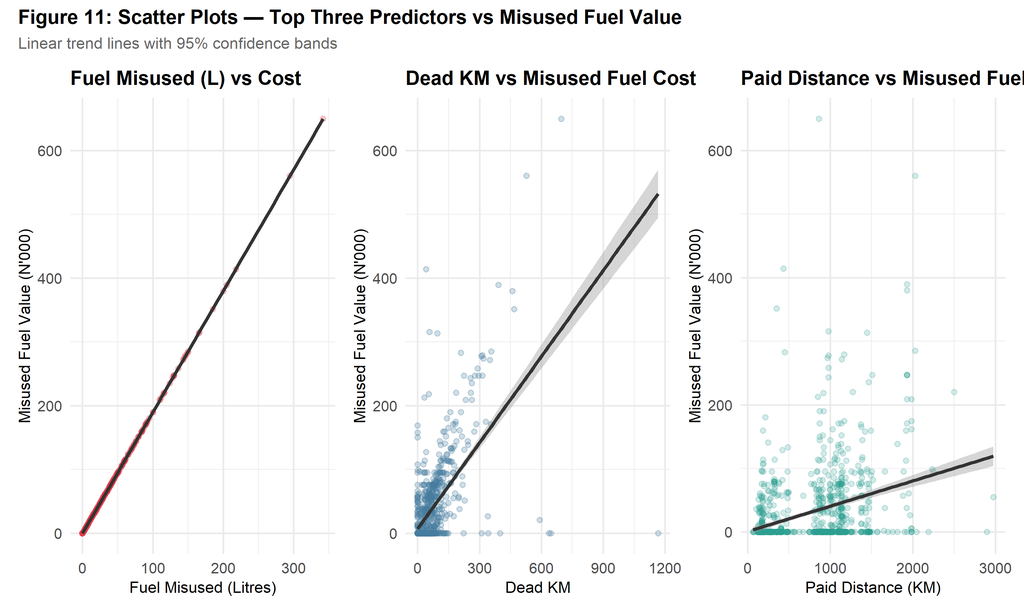

```r
p_a <- ggplot(df_clean, aes(x = fuel_misused_L, y = misused_value / 1000)) +
  geom_point(alpha = 0.25, colour = "#E63946", size = 1.5) +
  geom_smooth(method = "lm", se = TRUE, colour = "grey20") +
  scale_y_continuous(labels = label_comma()) +
  labs(title = "Fuel Misused (L) vs Cost",
       x = "Fuel Misused (Litres)", y = "Misused Fuel Value (N'000)")

p_b <- ggplot(df_clean, aes(x = dead_km, y = misused_value / 1000)) +
  geom_point(alpha = 0.25, colour = "#457B9D", size = 1.5) +
  geom_smooth(method = "lm", se = TRUE, colour = "grey20") +
  scale_y_continuous(labels = label_comma()) +
  labs(title = "Dead KM vs Misused Fuel Cost",
       x = "Dead KM", y = "Misused Fuel Value (N'000)")

p_c <- ggplot(df_clean, aes(x = paid_km, y = misused_value / 1000)) +
  geom_point(alpha = 0.2, colour = "#2A9D8F", size = 1.5) +
  geom_smooth(method = "lm", se = TRUE, colour = "grey20") +
  scale_y_continuous(labels = label_comma()) +
  labs(title = "Paid Distance vs Misused Fuel Cost",
       x = "Paid Distance (KM)", y = "Misused Fuel Value (N'000)")

(p_a | p_b | p_c) +
  plot_annotation(
    title    = "Figure 11: Scatter Plots — Top Three Predictors vs Misused Fuel Value",
    subtitle = "Linear trend lines with 95% confidence bands"
  )
```

**Causation note:** The dead KM–waste relationship is the most plausibly causal of the three. A controlled pilot — GPS-enforcing dead-KM caps on a randomly selected cohort of long-haul routes — would establish causality and quantify the intervention effect before full rollout.

# 9 Technique 5 — Multiple Linear Regression

## 9.1 Model Specification

The outcome variable is `log1p(misused_value)` — log-transformed to address the severe right-skew confirmed in the EDA. Predictors were selected on theoretical grounds, not stepwise search:

- `paid_km` — contracted route distance (route complexity and supervision difficulty)
- `dead_km` — non-revenue distance (route inefficiency, primary focus variable)
- `fuel_used_L` — total fuel consumed (scale of operation)
- `trip_days` — trip duration (proxy for supervisory oversight difficulty)
- `controller` — fleet controller identity (categorical accountability factor)
- `route_type` — route tier (structural route characteristic)

```r
df_model <- df_clean |>
  mutate(
    log_waste  = log1p(misused_value),
    controller = factor(controller),
    route_type = factor(route_type)
  ) |>
  select(log_waste, misused_value, paid_km, dead_km, fuel_used_L,
         trip_days, controller, route_type) |>
  drop_na()

cat("Modelling dataset:", nrow(df_model), "observations\n")
```

```
Modelling dataset: 1073 observations
```

```r
cat("Reference level (controller):", levels(df_model$controller)[1], "\n")
```

```
Reference level (controller): Dare Adediran
```

```r
cat("Reference level (route_type):", levels(df_model$route_type)[1], "\n")
```

```
Reference level (route_type): Short-haul (<=300 km)
```

```r
# =========================
# MODELS
# =========================

m1 <- lm(log_waste ~ paid_km + dead_km + fuel_used_L + trip_days,
         data = df_model)

m2 <- lm(log_waste ~ paid_km + dead_km + fuel_used_L + trip_days +
           controller + route_type,
         data = df_model)

# =========================
# MODEL METRICS TABLE
# =========================

model_metrics <- tibble(
  Model = c("Model 1 (Numeric Only)", "Model 2 (Full Model)"),
  `Adj R-squared` = c(
    summary(m1)$adj.r.squared,
    summary(m2)$adj.r.squared
  ),
  AIC = c(
    AIC(m1),
    AIC(m2)
  )
) |>
  mutate(across(where(is.numeric), ~round(.x, 4)))

model_metrics %>%
  kable(
    caption = "Model Comparison: Predicting Log Waste",
    align = "c",
    booktabs = TRUE
  ) %>%
  kable_styling(
    bootstrap_options = c("striped", "hover", "condensed", "responsive"),
    full_width = FALSE,
    position = "center",
    font_size = 13
  ) %>%
  row_spec(0, bold = TRUE, color = "white", background = "#1F4E79")
```

Model Comparison: Predicting Log Waste

| Model | Adj R-squared | AIC |
| --- | --- | --- |
| Model 1 (Numeric Only) | 0.4662 | 5942.829 |
| Model 2 (Full Model) | 0.4818 | 5916.802 |

```r
# =========================
# ANOVA MODEL COMPARISON
# =========================

anova_result <- anova(m1, m2)

anova_tbl <- as.data.frame(anova_result) |>
  tibble::rownames_to_column("Model Comparison") |>
  mutate(across(where(is.numeric), ~round(.x, 4)))

anova_tbl %>%
  kable(
    caption = "Nested Model Comparison (ANOVA)",
    align = "c",
    booktabs = TRUE
  ) %>%
  kable_styling(
    bootstrap_options = c("striped", "hover", "responsive"),
    full_width = FALSE,
    position = "center",
    font_size = 13
  ) %>%
  row_spec(0, bold = TRUE, color = "white", background = "#7A0019")
```

Nested Model Comparison (ANOVA)

| Model Comparison | Res.Df | RSS | Df | Sum of Sq | F | Pr(>F) |
| --- | --- | --- | --- | --- | --- | --- |
| 1 | 1068 | 15798.49 | NA | NA | NA | NA |
| 2 | 1062 | 15248.41 | 6 | 550.0876 | 6.3853 | 0 |

```r
m2_summary <- summary(m2)

# =========================
# MODEL OVERVIEW
# =========================

model_overview <- tibble(
  Metric = c(
    "R-squared",
    "Adjusted R-squared",
    "Residual Std. Error",
    "F-statistic"
  ),
  Value = c(
    m2_summary$r.squared,
    m2_summary$adj.r.squared,
    m2_summary$sigma,
    unname(m2_summary$fstatistic[1])
  )
) |>
  mutate(Value = round(Value, 4))

model_overview %>%
  kable(
    caption = "Model 2 Summary Overview",
    align = "c",
    booktabs = TRUE
  ) %>%
  kable_styling(
    bootstrap_options = c("striped", "hover", "condensed", "responsive"),
    full_width = FALSE,
    position = "center",
    font_size = 13
  ) %>%
  row_spec(0, bold = TRUE, color = "white", background = "#1F4E79")
```

Model 2 Summary Overview

| Metric | Value |
| --- | --- |
| R-squared | 0.4867 |
| Adjusted R-squared | 0.4818 |
| Residual Std. Error | 3.7892 |
| F-statistic | 100.6827 |

```r
# =========================
# COEFFICIENT TABLE
# =========================

coef_tbl <- broom::tidy(m2) |>
  mutate(
    estimate = round(estimate, 4),
    std.error = round(std.error, 4),
    statistic = round(statistic, 4),
    p.value = round(p.value, 4)
  )

coef_tbl %>%
  kable(
    caption = "Model 2 Coefficients",
    align = "c",
    booktabs = TRUE
  ) %>%
  kable_styling(
    bootstrap_options = c("striped", "hover", "responsive"),
    full_width = FALSE,
    position = "center",
    font_size = 12
  ) %>%
  row_spec(0, bold = TRUE, color = "white", background = "#7A0019")
```

Model 2 Coefficients

| term | estimate | std.error | statistic | p.value |
| --- | --- | --- | --- | --- |
| (Intercept) | 2.0018 | 0.3387 | 5.9108 | 0.0000 |
| paid_km | -0.0271 | 0.0015 | -18.6391 | 0.0000 |
| dead_km | 0.0061 | 0.0017 | 3.5753 | 0.0004 |
| fuel_used_L | 0.0563 | 0.0028 | 20.3998 | 0.0000 |
| trip_days | 0.0506 | 0.0321 | 1.5743 | 0.1157 |
| controllerDeborah James | -1.1495 | 0.4206 | -2.7327 | 0.0064 |
| controllerKayode Adebisi | -0.8026 | 0.3562 | -2.2534 | 0.0244 |
| controllerOluwadamilare Adeniran | -1.2560 | 0.3644 | -3.4465 | 0.0006 |
| controllerVincent Ojo | -0.7597 | 0.3555 | -2.1370 | 0.0328 |
| route_typeMedium-haul (301-700 km) | 1.8395 | 0.3995 | 4.6043 | 0.0000 |
| route_typeLong-haul (>700 km) | 1.8603 | 0.5614 | 3.3135 | 0.0010 |

```r
coef_tbl <- tidy(m2, conf.int = TRUE) |>
  mutate(
    Significant = ifelse(p.value < 0.05, "Yes", "No"),
    across(c(estimate, std.error, statistic, conf.low, conf.high),
           ~round(.x, 4))
  )

kable(coef_tbl,
      caption = "Table 5: Regression Coefficients — Full Model (Outcome: log(1 + Misused Value N))",
      col.names = c("Term", "Estimate", "Std. Error", "t",
                    "p-value", "CI Low", "CI High", "Significant")) |>
  kable_styling(bootstrap_options = c("striped", "hover", "condensed"),
                full_width = FALSE) |>
  row_spec(which(coef_tbl$Significant == "Yes"), background = "#f0f7f0")
```

Table 5: Regression Coefficients — Full Model (Outcome: log(1 + Misused Value N))

| Term | Estimate | Std. Error | t | p-value | CI Low | CI High | Significant |
| --- | --- | --- | --- | --- | --- | --- | --- |
| (Intercept) | 2.0018 | 0.3387 | 5.9108 | 0.0000000 | 1.3373 | 2.6664 | Yes |
| paid_km | -0.0271 | 0.0015 | -18.6391 | 0.0000000 | -0.0299 | -0.0242 | Yes |
| dead_km | 0.0061 | 0.0017 | 3.5753 | 0.0003656 | 0.0028 | 0.0095 | Yes |
| fuel_used_L | 0.0563 | 0.0028 | 20.3998 | 0.0000000 | 0.0509 | 0.0618 | Yes |
| trip_days | 0.0506 | 0.0321 | 1.5743 | 0.1157167 | -0.0125 | 0.1137 | No |
| controllerDeborah James | -1.1495 | 0.4206 | -2.7327 | 0.0063854 | -1.9748 | -0.3241 | Yes |
| controllerKayode Adebisi | -0.8026 | 0.3562 | -2.2534 | 0.0244389 | -1.5014 | -0.1037 | Yes |
| controllerOluwadamilare Adeniran | -1.2560 | 0.3644 | -3.4465 | 0.0005901 | -1.9711 | -0.5409 | Yes |
| controllerVincent Ojo | -0.7597 | 0.3555 | -2.1370 | 0.0328297 | -1.4573 | -0.0621 | Yes |
| route_typeMedium-haul (301-700 km) | 1.8395 | 0.3995 | 4.6043 | 0.0000046 | 1.0556 | 2.6234 | Yes |
| route_typeLong-haul (>700 km) | 1.8603 | 0.5614 | 3.3135 | 0.0009524 | 0.7587 | 2.9620 | Yes |

## 9.2 Diagnostic Plots

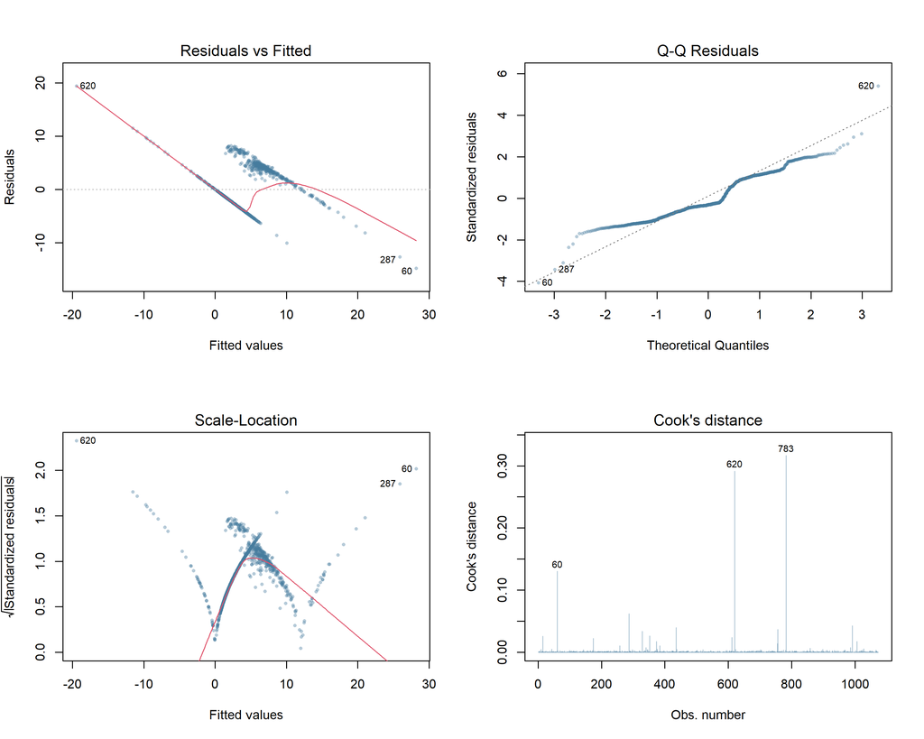

```r
par(mfrow = c(2, 2))
plot(m2, which = 1:4,
     col  = adjustcolor("#457B9D", alpha.f = 0.4),
     pch  = 16, cex = 0.6)
```

```r
par(mfrow = c(1, 1))
```

```r
cat("=== Variance Inflation Factors (VIF) ===\n")
```

```
=== Variance Inflation Factors (VIF) ===
```

```r
vif_vals <- vif(m2)

vif_tbl <- tibble(
  Variable = names(vif_vals),
  VIF = as.numeric(vif_vals)
) |>
  mutate(
    VIF = round(VIF, 3),
    Status = case_when(
      VIF < 5 ~ "OK",
      VIF < 10 ~ "Moderate",
      TRUE ~ "Severe"
    )
  )

vif_tbl %>%
  kable(
    caption = "Variance Inflation Factors (Multicollinearity Check)",
    align = "c",
    booktabs = TRUE
  ) %>%
  kable_styling(
    bootstrap_options = c("striped", "hover", "condensed", "responsive"),
    full_width = FALSE,
    position = "center",
    font_size = 13
  ) %>%
  row_spec(
    0,
    bold = TRUE,
    color = "white",
    background = "#1F4E79"
  )
```

Variance Inflation Factors (Multicollinearity Check)

| VIF | Status |
| --- | --- |
| 41.123 | Severe |
| 1.531 | OK |
| 40.126 | Severe |
| 1.455 | OK |
| 1.026 | OK |
| 5.380 | Moderate |
| 1.000 | OK |
| 1.000 | OK |
| 1.000 | OK |
| 1.000 | OK |
| 4.000 | OK |
| 2.000 | OK |
| 6.413 | Moderate |
| 1.237 | OK |
| 6.335 | Moderate |
| 1.206 | OK |
| 1.003 | OK |
| 1.523 | OK |

```r
cat("\nNote: VIF > 10 indicates severe multicollinearity; < 5 is acceptable.\n")
```

```
Note: VIF > 10 indicates severe multicollinearity; < 5 is acceptable.
```

## 9.3 Business Interpretation of Coefficients

```r
key_coefs <- coef_tbl |>
  filter(term %in% c("dead_km", "paid_km", "fuel_used_L", "trip_days")) |>
  mutate(
    pct_change_per_unit = round((exp(estimate) - 1) * 100, 3)
  ) |>
  select(term, estimate, p.value, pct_change_per_unit, Significant)

kable(key_coefs,
      caption = "Table 6: Back-transformed Coefficient Interpretation",
      col.names = c("Variable", "Log-scale Coefficient", "p-value",
                    "Approx. % change in waste value per unit increase",
                    "Significant")) |>
  kable_styling(bootstrap_options = c("striped", "hover"), full_width = FALSE)
```

Table 6: Back-transformed Coefficient Interpretation

| Variable | Log-scale Coefficient | p-value | Approx. % change in waste value per unit increase | Significant |
| --- | --- | --- | --- | --- |
| paid_km | -0.0271 | 0.0000000 | -2.674 | Yes |
| dead_km | 0.0061 | 0.0003656 | 0.612 | Yes |
| fuel_used_L | 0.0563 | 0.0000000 | 5.792 | Yes |
| trip_days | 0.0506 | 0.1157167 | 5.190 | No |

**Plain-language interpretation for a non-technical manager:**

# 10 Integrated Findings

Taken together, the five techniques converge on a single, evidence-based conclusion:

**Fuel waste in AB InBev’s Sagamu Transport Operations is neither random nor uniformly distributed. It is concentrated on long-haul routes, high dead-kilometre trips, and specific controller teams — and it is both quantifiable and predictable.**

# 11 Limitations & Further Work

1. **Single client, single hub:** All 1,073 trips come from one client (AB InBev) dispatched from Sagamu. Findings may not generalise to other clients, origins, vehicle types, or fuel price regimes. A multi-client analysis across DP World MDS’s full Nigeria portfolio would be a natural next step.
2. **Associational, not causal:** The regression establishes associations, not causal effects. To confirm that GPS-enforced dead-KM caps reduce waste in the predicted magnitude, a controlled pilot — applying the intervention to a randomly selected cohort of long-haul routes — would be required before full rollout.
3. **Fuel price assumed constant:** The dataset implies a fixed ₦1,900 per litre conversion for misused fuel value. Any fuel price fluctuations during Q1 2026 would introduce noise into month-to-month comparisons. Future analyses should incorporate a live fuel price index.
4. **Missing load and cargo data:** Vehicle load factor (cargo weight relative to capacity) affects fuel consumption independently of distance. A more complete model would include load factor as a covariate, which would likely reduce the coefficient on `fuel_used_L` and improve model fit.
5. **Further work:** A **time series model** (ARIMA or Prophet) applied to weekly waste expenditure could forecast Q2 2026 costs and evaluate whether the March improvement trend is sustained. A **classification model** (logistic regression or random forest) could flag individual trips likely to generate waste before departure, enabling pre-emptive fuel verification checks. Extending the analysis to Q2 and Q3 2026 would confirm whether Q1 patterns are seasonal or structural.

# 12 Document Access

**Published report:** [RPubs — Reducing Fuel Misuse and Improving Profitability per Trip](https://rpubs.com/anthoniaokocha/1432977)

**Source code & data:** [GitHub — anthoniaokocha/Reducing-Fuel-misuse-and-Improving-Profitability-per-Trip](https://github.com/anthoniaokocha/Reducing-Fuel-misuse-and-Improving-Profitability-per-Trip)

# 13 References

Adi, B. (2026). *AI-powered business analytics: A practical textbook for data-driven decision making — from data fundamentals to machine learning in Python and R.* Lagos Business School / markanalytics.online. https://markanalytics.online

R Core Team. (2024). *R: A language and environment for statistical computing* (Version 4.x). R Foundation for Statistical Computing. https://www.R-project.org/

Wickham, H., Averick, M., Bryan, J., Chang, W., McGowan, L., Francois, R., Grolemund, G., Hayes, A., Henry, L., Hester, J., Kuhn, M., Pedersen, T. L., Miller, E., Bache, S. M., Muller, K., Ooms, J., Robinson, D., Seidel, D. P., Spinu, V., & Yutani, H. (2019). Welcome to the tidyverse. *Journal of Open Source Software, 4*(43), 1686. https://doi.org/10.21105/joss.01686

Wickham, H. (2016). *ggplot2: Elegant graphics for data analysis.* Springer. https://doi.org/10.1007/978-3-319-24277-4

Taylor, S. J., & Letham, B. (2018). Forecasting at scale. *The American Statistician, 72*(1), 37–45. https://doi.org/10.1080/00031305.2017.1380080

Okocha, A. (2026). *AB InBev Q1 2026 trip review report — Sagamu Transport Operations* [Dataset]. Collected from DP World MDS Sagamu Transport Operations, Sagamu, Nigeria. Data available on request from the author.

```r
pkgs <- c("readxl", "lubridate", "corrplot", "GGally", "broom", "car",
          "moments", "effectsize", "patchwork", "ggridges", "viridis", "kableExtra")
cat("**R package citations** (run `citation('packagename')` in R for full BibTeX entry):\n\n")
```

**R package citations** (run `citation('packagename')` in R for full BibTeX entry):

```r
for (p in pkgs) {
  cat(paste0("- `", p, "` — retrieve via `citation('", p, "')`\n"))
}
```

- `readxl` — retrieve via `citation('readxl')`
- `lubridate` — retrieve via `citation('lubridate')`
- `corrplot` — retrieve via `citation('corrplot')`
- `GGally` — retrieve via `citation('GGally')`
- `broom` — retrieve via `citation('broom')`
- `car` — retrieve via `citation('car')`
- `moments` — retrieve via `citation('moments')`
- `effectsize` — retrieve via `citation('effectsize')`
- `patchwork` — retrieve via `citation('patchwork')`
- `ggridges` — retrieve via `citation('ggridges')`
- `viridis` — retrieve via `citation('viridis')`
- `kableExtra` — retrieve via `citation('kableExtra')`

# 14 Appendix: AI Usage Statement